# Final Exam

Wei Shi

# 1 Problem 1

## 1.1 (a)

The zero-inflated Poisson is a mixture of a Poisson and a Bernoulli distribution,
$$\begin{align}
Y=V(1-B),
\end{align}$$

where $V \sim \text{Poisson}(\lambda), B \sim \text{Bernoulli}(\xi)$, and $V$ and $B$ are independent.

Thus,
$$\begin{align}
P(Y=0 \text{ from Bernoulli}) & = P(B=1) = \xi \\
P(Y=0 \text{ from Poisson}) & =P(B=0,V=0) = (1-\xi)e^{-\lambda} \\
P(Y=i) & = P(B=0,V=i) = (1-\xi)\frac{\lambda^i e^{-\lambda}}{i!}, i = 1,2,\ldots
\end{align}$$
Therefore, the complete-data likelihood can be written as
$$\begin{align}
l^c(\xi, \lambda) & = \log \left\{\xi^{z_b}[(1-\xi)e^{-\lambda}]^{z_p}
\prod_{i=1}^{\infty}\left[(1-\xi)\frac{\lambda^i e^{-\lambda}}{i!}\right]^{n_i}\right\} \\
& = z_b \log \xi + z_p [\log(1-\xi) - \lambda] + \sum_{i=1}^{\infty} n_i [\log(1-\xi) + i\log \lambda - \lambda - \log(i!)]
\end{align}$$

## 1.2 (b)

### 1.2.1 E-step: Compute the conditional expectation of $l^c(\xi, \lambda)$

Denote the observed data as $\boldsymbol{n} = (n_0, n_1, n_2, \ldots)$. We have that
$$\begin{align}
Q(\xi, \lambda|\xi_t, \lambda_t)
& = \sum_{z_b} \sum_{z_p} l^c(\xi, \lambda) p(z_b,z_p|\boldsymbol{n}, \xi_t, \lambda_t) \\
& = \log \xi \sum_{z_b} \sum_{z_p} z_b p(z_b,z_p|\boldsymbol{n}, \xi_t, \lambda_t) +
[\log(1-\xi) - \lambda] \sum_{z_b} \sum_{z_p} z_p p(z_b,z_p|\boldsymbol{n}, \xi_t, \lambda_t) +
\sum_{i=1}^{\infty} n_i [\log(1-\xi) + i\log \lambda - \lambda - \log(i!)] \\
& = \log \xi \sum_{z_b} z_b p(z_b|\boldsymbol{n}, \xi_t, \lambda_t) +
[\log(1-\xi) - \lambda] \sum_{z_p} z_p p(z_p|\boldsymbol{n}, \xi_t, \lambda_t) +
\sum_{i=1}^{\infty} n_i [\log(1-\xi) + i\log \lambda - \lambda - \log(i!)] \\
& = b_{t+1} \log \xi + p_{t+1}[\log(1-\xi) - \lambda] +
\sum_{i=1}^{\infty} n_i [\log(1-\xi) + i\log \lambda - \lambda - \log(i!)], \\
\end{align}$$
where
$$\begin{align}
b_{t+1} & = \sum_{z_b} z_b p(z_b|\boldsymbol{n}, \xi_t, \lambda_t) = E(z_b|n_0, \xi_t, \lambda_t) = n_0 \frac{\xi_t}{\xi_t + (1-\xi_t)e^{-\lambda_t}} \text{ since } z_b|n_0, \xi_t, \lambda_t \sim \text{Binomial}\left(n_0, \frac{\xi_t}{\xi_t + (1-\xi_t)e^{-\lambda_t}}\right) \\
p_{t+1} & = \sum_{z_p} z_p p(z_p|\boldsymbol{n}, \xi_t, \lambda_t) = E(z_p|n_0, \xi_t, \lambda_t) = n_0 \frac{(1-\xi_t)e^{-\lambda_t}}{\xi_t + (1-\xi_t)e^{-\lambda_t}} = n_0 - b_{t+1} \text{ since } z_p|n_0, \xi_t, \lambda_t \sim \text{Binomial}\left(n_0, \frac{(1-\xi_t)e^{-\lambda_t}}{\xi_t + (1-\xi_t)e^{-\lambda_t}}\right)
\end{align}$$

### 1.2.2 M-step: Maximize $Q(\xi, \lambda|\xi_t, \lambda_t)$ to obtain $(\xi_{t+1}, \lambda_{t+1})$

Take derivative of $Q(\xi, \lambda|\xi_t, \lambda_t)$ w.r.t. $\xi$ and $\lambda$ and set to zero, we have that
$$\begin{align}
\frac{\partial Q(\xi, \lambda|\xi_t, \lambda_t)}{\partial \xi}
& = \frac{b_{t+1}}{\xi} - \frac{p_{t+1} + \sum_{i=1}^{\infty} n_i}{1-\xi} = 0\\
\frac{\partial Q(\xi, \lambda|\xi_t, \lambda_t)}{\partial \lambda}
& = \frac{\sum_{i=1}^{\infty} i \cdot n_i}{\lambda} - (p_{t+1} + \sum_{i=1}^{\infty} n_i)= 0\\
\end{align}$$
Solve the above two equations, we can get that
$$\begin{align}
\xi_{t+1} & = \frac{b_{t+1}}{b_{t+1} + p_{t+1} + \sum_{i=1}^{\infty} n_i} = \frac{b_{t+1}}{\sum_{i=0}^{\infty} n_i}\\
\lambda_{t+1} & = \frac{\sum_{i=1}^{\infty} i \cdot n_i}{p_{t+1} + \sum_{i=1}^{\infty} n_i} = \frac{\sum_{i=0}^{\infty} i \cdot n_i}{\sum_{i=0}^{\infty} n_i - b_{t+1}}\\
\end{align}$$

## 1.3 (c)

```r
MyEM <- function(data, xi0, lambda0, tol = 1e-06){
  # Compute the MLE of xi and lambda by EM algorithm.
  #
  # Args:
  #   data: data frame with variables i and ni.
  #   xi0: initial value of xi.
  #   lambda0: initial value of lambda.
  #   tol: the desired accuracy. Default is 1e-06.
  #
  # Returns:
  #   MLE of xi and lambda.
  xi <- xi0
  lambda <- lambda0
  print(paste("Initial value: xi =", xi, ", lambda =", lambda))

  sum.ni <- sum(data$ni)
  sum.ini <- sum(data$i * data$ni)
  diff <- 1
  i <- 1

  print("Results of first 10 iterations:")
  while(diff > tol){
    b <- data$ni[1] * xi / (xi + (1 - xi) * exp(-lambda))
    xi.new <- b / sum.ni
    lambda.new <- sum.ini / (sum.ni - b)
    if(i <= 10) print(paste("Iteration", i, ": xi =", xi.new, ", lambda =", lambda.new))
    diff <- sqrt((xi.new - xi)^2 + (lambda.new - lambda)^2)
    xi <- xi.new
    lambda <- lambda.new
    i <- i + 1
  }
  return(data.frame(xi,lambda))
}
```

## 1.4 (d)

```r
dat <- data.frame(i  = 0:6,
                  ni = c(3062, 587, 284, 103, 33, 4, 2))

set.seed(6218)
xi0 <- 0.75
lambda0 <- 0.40
result1d <- MyEM(dat, xi0, lambda0)
```

```
## [1] "Initial value: xi = 0.75 , lambda = 0.4"
## [1] "Results of first 10 iterations:"
## [1] "Iteration 1 : xi = 0.614178900085071 , lambda = 1.03547784852118"
## [1] "Iteration 2 : xi = 0.614378226814955 , lambda = 1.03601308389368"
## [1] "Iteration 3 : xi = 0.614532384555037 , lambda = 1.03642741036187"
## [1] "Iteration 4 : xi = 0.614651571373347 , lambda = 1.03674797345821"
## [1] "Iteration 5 : xi = 0.614743697997179 , lambda = 1.03699589176626"
## [1] "Iteration 6 : xi = 0.614814894737621 , lambda = 1.0371875677328"
## [1] "Iteration 7 : xi = 0.614869908541352 , lambda = 1.03733572451033"
## [1] "Iteration 8 : xi = 0.614912412974428 , lambda = 1.03745022149327"
## [1] "Iteration 9 : xi = 0.614945249628868 , lambda = 1.03753869305319"
## [1] "Iteration 10 : xi = 0.614970615764176 , lambda = 1.03760704717876"
```

```r
knitr::kable(result1d, booktabs = TRUE, digits = 8,
             caption = 'MLE of \(\xi\) and \(\lambda\) by EM algorithm.')
```

Table 1.1: MLE of $\xi$ and $\lambda$ by EM algorithm.

| xi | lambda |
| --- | --- |
| 0.6150556 | 1.037836 |

# 2 Problem 2

## 2.1 (a)

$$\begin{align}
N(5) \sim \text{Poisson}(Z),
\end{align}$$
where
$$\begin{align}
Z = \int_0^5 \lambda(t) dt = \int_0^5 [\sqrt{t} + e^{-t}\sin(2\pi t)] dt \approx 7.60774
\end{align}$$

## 2.2 (b)

Since
$$\begin{align}
\lambda(t) = \sqrt{t} + e^{-t}\sin(2\pi t) \leq \sqrt{t} + e^{-t} \leq \sqrt{5} + e^{-5}, t \in [0,5],
\end{align}$$

with $\lambda_0 = \sqrt{5} + e^{-5}$, we can design the procedure to simulate from this Poisson process as follows:

Step 1: Sample ${\tau_i}$ from a Poisson process with intensity $\lambda_0$ in [0, 5]

Step 2: For each $i$, retain ${\tau_i}$ with probability $\lambda(\tau_i)/\lambda_0$

Step 3: Return the retained ${\tau_i}$

```r
lambda <- function(t) sqrt(t) + exp(-t) * sin(2 * pi * t)

MySimu <- function(lambda0){
  t <- 5
  N <- rpois(1, lambda0 * t)
  S <- sort(runif(N) * t)
  X <- numeric()
  if(N != 0){
    for(i in 1:N){
      if(runif(1) < lambda(S[i]) / lambda0){
        X <- c(X, S[i])
      }
    }
  }
  return(X)
}
```

## 2.3 (c)

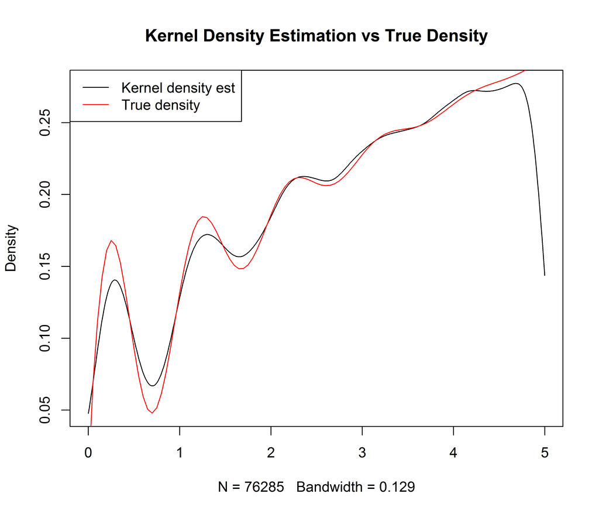

```r
lambda0 <- sqrt(5) + exp(-5)
nrep <- 10000
sample <- unlist(replicate(nrep, MySimu(lambda0)))

plot(density(sample, from = 0, to = max(sample)),
     main = "Kernel Density Estimation vs True Density")
  curve(sapply(x, function(x) lambda(x) / 7.60774), from = 0, to = max(sample),
        col = "red", add = TRUE)
  legend("topleft",c("Kernel density est","True density"), col = c("black", "red"), lty = 1)
```

From the above plot, we can see that two curves are quite close.

# 3 Problem 3

## 3.1 (a)

$$\begin{align}
R(x,y|x_0,y_0) = \frac{f(x,y)k(x_0,y_0|x,y)}{f(x_0,y_0)k(x,y|x_0,y_0)}
= \frac{\frac{e^{-x}(1-y)^{\tau-1}}{x+\theta y}e^{-x_0}(1-y_0)^{\tau - 1}}{\frac{e^{-x_0}(1-y_0)^{\tau-1}}{x_0+\theta y_0}e^{-x}(1-y)^{\tau - 1}}
= \frac{x_0 + \theta y_0}{x + \theta y}
\end{align}$$

## 3.2 (b)

```r
MyMH <- function(tau, theta, n, nburn){
  total.n <- n + nburn
  x.sample <- y.sample <- vector(length = total.n)
  x.sample[1] <- y.sample[1] <- 0.5 #initial value
  for(i in 1:(total.n - 1)){
    x <- rexp(1)
    y <- rbeta(1, 1, tau)
    u <- runif(1)
    r <- (x.sample[i] + theta * y.sample[i]) / (x + theta * y)
    if (u <= min(r, 1)){
      x.sample[i + 1] <- x
      y.sample[i + 1] <- y
    } else{
      x.sample[i + 1] <- x.sample[i]
      y.sample[i + 1] <- y.sample[i]
    }
  }
  return(data.frame(x = tail(x.sample, n), y = tail(y.sample, n)))
}
```

## 3.3 (c)

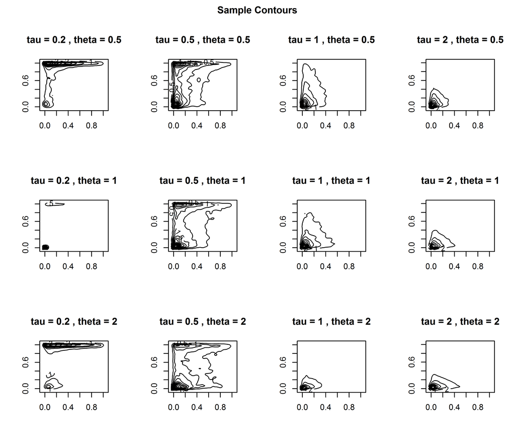

```r
MySampleContour <- function(tau, theta, n, nburn){
  sample <- MyMH(tau, theta, n, nburn)
  sample <- sample[sample$x <= 1,]
  est <- bkde2D(sample, bandwidth = c(5 / sqrt(n), 5 / sqrt(n)))
  contour(est$x1, est$x2, est$fhat, main = paste("tau =", tau, ", theta =", theta))
}

vMySampleContour <- Vectorize(MySampleContour, c("tau", "theta"))

n <- 30000
nburn <- 5000
tau <- c(0.2, 0.5, 1, 2)
theta <- c(0.5, 1, 2)

par(mfrow = c(3, 4), oma = c(0, 0, 2, 0))
outer(tau, theta, vMySampleContour, n, nburn)
title("Sample Contours", outer = TRUE)
```

# 4 Problem 4

## 4.1 (a)

Here we have that $f$ is the density of $N((r-\sigma^2/2)T, \sigma^2T)$, and $g$ is the density of $N((\mu-\sigma^2/2)T, \sigma^2T)$. Then, the importance ratio can be calculated as
$$\begin{align}
w(x)=\frac{f(x)}{g(x)} & =
\frac{\frac{1}{\sqrt{2\pi\sigma^2T}}\exp\left\{-\frac{[x-(r-\sigma^2/2)T]^2}{2\sigma^2T}\right\}}
{\frac{1}{\sqrt{2\pi\sigma^2T}}\exp\left\{-\frac{[x-(\mu-\sigma^2/2)T]^2}{2\sigma^2T}\right\}} \\
& = \exp\left\{\frac{[x-(\mu-\sigma^2/2)T]^2 - [x-(r-\sigma^2/2)T]^2}{2\sigma^2T}\right\} \\
& = \exp\left\{\frac{(r-\mu)[2x-(\mu + r - \sigma^2)T]}{2\sigma^2}\right\}
\end{align}$$

```r
MyIS <- function(n, mu, t, r, S0, K, sigma){
  x <- rnorm(n, (mu - sigma^2 / 2) * t, sigma * sqrt(t))
  w <- exp((r - mu) * (2 * x - (mu + r - sigma^2) * t) / (2 * sigma^2))
  h <- exp(-r * t) * pmax(S0 * exp(x) - K, 0)
  return(mean(h * w))
}
```

## 4.2 (b)

```r
vMyIS <- Vectorize(MyIS, "mu")

MyRep <- function(n, t, r, S0, K, sigma, nrep){
  mu <- c(r, log(K / S0))
  MCIS <- replicate(nrep, vMyIS(n, mu, t, r, S0, K, sigma))
  mean <- apply(MCIS, 1, mean)
  sd <- apply(MCIS, 1, sd)
  return(data.frame(mean, sd, row.names = c("MC", "IS")))
}

set.seed(6218)
t <- 0.25
S0 <- 10
K <- 15
sigma <- 0.2
r <- 0.05
n <- 10000
nrep <- 1000

result4b <- MyRep(n, t, r, S0, K, sigma, nrep)
knitr::kable(result4b, booktabs = TRUE,
             caption = 'Mean and standard error of the approximated value from crude Monte Carlo (MC) and importance sampling (IS).')
```

Table 4.1: Mean and standard error of the approximated value from crude Monte Carlo (MC) and importance sampling (IS).

[output not shown]

From the table above, we can see that the mean of the approximated value from crude Monte Carlo and importance sampling are quite close, but the standard error from importance sampling is smaller.

## 4.3 (c)

```r
result4c1 <- MyRep(n, t, r, S0, 12.5, sigma, nrep)
result4c2 <- MyRep(n, t, r, S0, 17.5, sigma, nrep)

knitr::kable(result4c1, booktabs = TRUE, digits = 8,
             caption = 'Mean and standard error of the approximated value from crude Monte Carlo (MC) and importance sampling (IS) with \(K = 12.5\).')
```

Table 4.2: Mean and standard error of the approximated value from crude Monte Carlo (MC) and importance sampling (IS) with $K = 12.5$.

|  | mean | sd |
| --- | --- | --- |
| MC | 0.00707273 | 0.00079948 |
| IS | 0.00703701 | 0.00040548 |

```r
knitr::kable(result4b, booktabs = TRUE, digits = 8,
             caption = 'Mean and standard error of the approximated value from crude Monte Carlo (MC) and importance sampling (IS) with \(K = 15\).')
```

Table 4.2: Mean and standard error of the approximated value from crude Monte Carlo (MC) and importance sampling (IS) with $K = 15$.

|  | mean | sd |
| --- | --- | --- |
| MC | 1.089e-05 | 2.627e-05 |
| IS | 1.166e-05 | 4.470e-06 |

```r
knitr::kable(result4c2, booktabs = TRUE, digits = 8,
             caption = 'Mean and standard error of the approximated value from crude Monte Carlo (MC) and importance sampling (IS) with \(K = 17.5\).')
```

Table 4.2: Mean and standard error of the approximated value from crude Monte Carlo (MC) and importance sampling (IS) with $K = 17.5$.

|  | mean | sd |
| --- | --- | --- |
| MC | 1.1e-07 | 3.26e-06 |
| IS | 1.0e-08 | 2.00e-08 |

From the above three tables, we can see that as $K$ increases, the mean and standard error of the approximated value become smaller for both methods. In all three cases, the standard error from importance sampling is smaller.